# Analyzing Individual BGG Users

Phil Henrickson

2022-01-01

# **Kameronsnewphone’s** BoardGameGeek Collection

This notebook contains a set of analyses for the selected user’s boardgamegeek collection. The bulk of the analysis is focused on building a user-specific predictive model to predict the games that Kameronsnewphone is likely to own. This enables to ask questions like, based on the games the user currently owns, what games are a good fit for their collection? What upcoming games are they likely to purchase?

This analysis is based on data from BoardGameGeek that was last updated on **2021-12-20.**

# 1 Collection Overview

We can look at a basic description of the number of games that the user owns, has rated, has previously owned, etc.

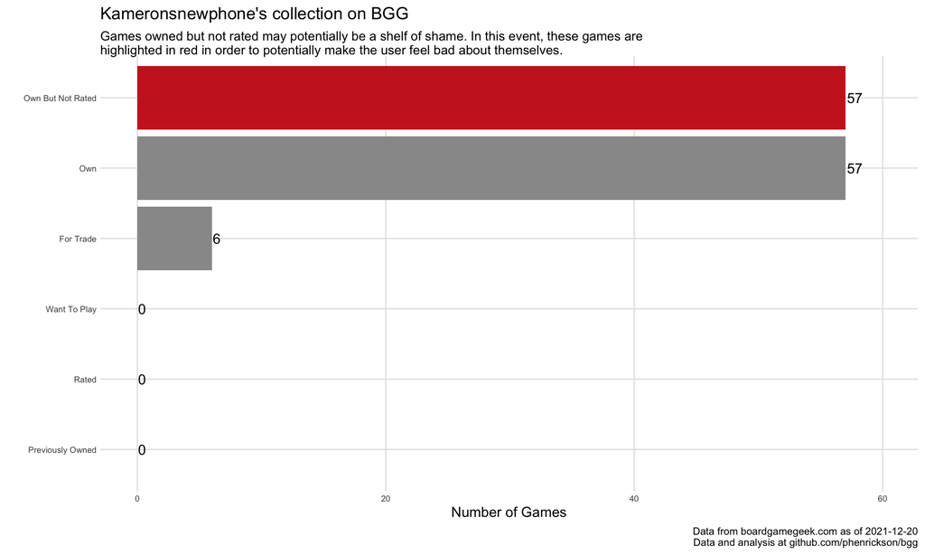

What years has the user owned/rated games from? While we can’t see when a user added or removed a game from their collection, we can look at their collection by the years in which their games were published.

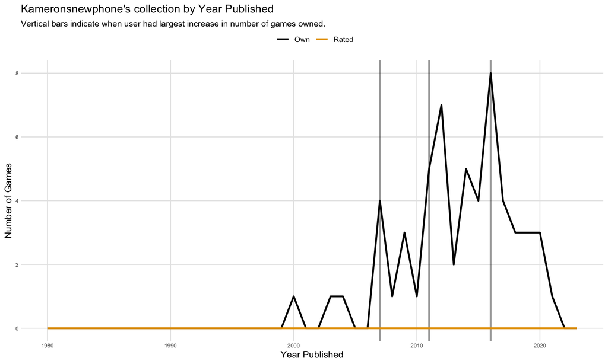

## 1.1 What types of games does Kameronsnewphone own?

We can look at the most frequent types of categories, mechanics, designers, and artists that appear in a user’s collection.

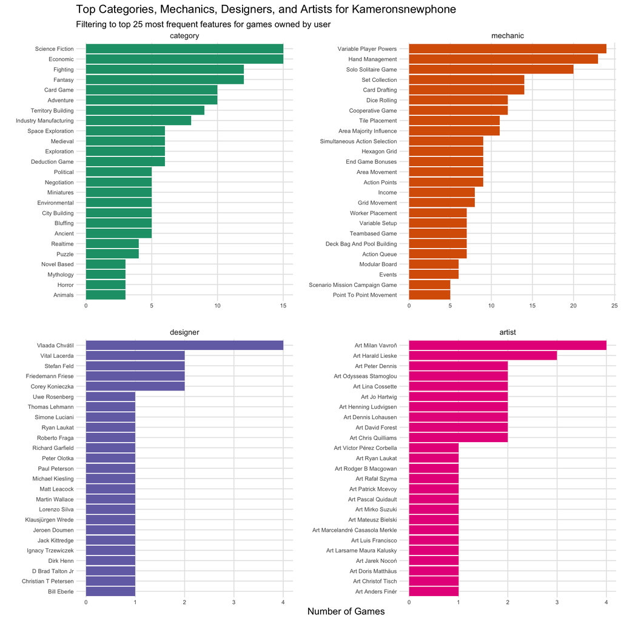

# 2 Modeling **Kameronsnewphone’s** Collection

We’ll examine a predictive model trained on a user’s collection for games published through 2019. How many games has the user owned/rated/played in the training set (games prior to 2019)?

| username | dataset | period | games_owned | games_rated | games_played |
| --- | --- | --- | --- | --- | --- |
| Kameronsnewphone | training | published before 2020 | 51 | 0 | 51 |
| Kameronsnewphone | test | published 2020 or later | 4 | 0 | 4 |

There are two main (binary) outcomes we will be modeling for the user.

The first, **own** refers to whether the user currently lists a game as owned in their collection. The second, **played** refers to whether the user currently owns, has rated, or previously owned a game. This means the latter will generally have a larger list of games, but may still be a useful category to examine for people who play lots of games without necessarily owning them.

We will train predictive models to learn the probability that the user will own or play individual games based on their features.

## 2.1 Coefficients for Kameronsnewphone

We can examine coefficients from the trained modes, which are penalized logistic regressions fit to our two main outcomes. Positive values indicate that a feature increases a user’s probabilility of owning/rating a game, while negative values indicate a feature decreases the probability.

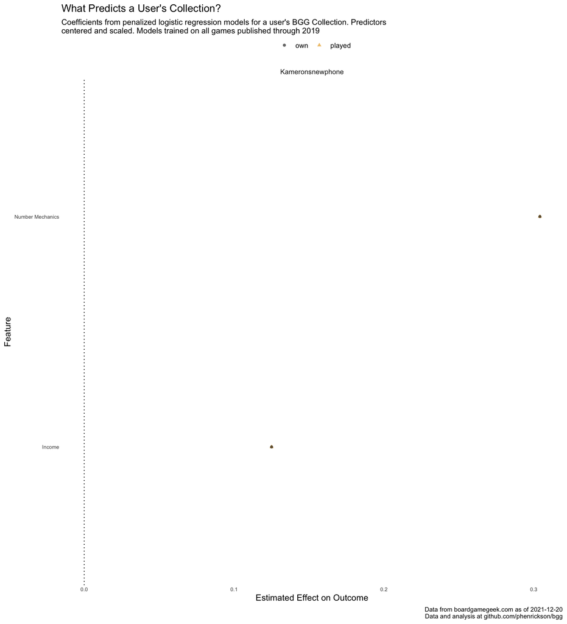

## 2.2 Visualizing Predictors for Kameronsnewphone’s Collection

Why did the model identify these features? We can make density plots of the important features for predicting whether the user owned a game. Blue indicates the density for games owned by the user, while grey indicates the density for games not owned by the user.

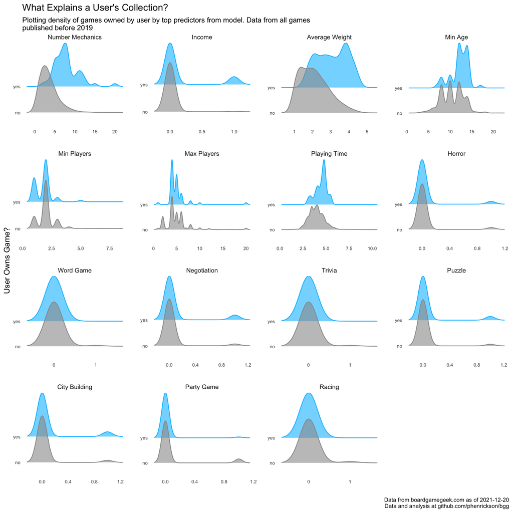

Binary predictors can be difficult to see with this visualization, so we can also directly examine the percentage of games in a user’s collection with a predictor vs the percentage of all games with that predictor.

| username | Feature | % of Games with Feature In_Collection | % of Games with Feature All_Games | Ratio |
| --- | --- | --- | --- | --- |
| Kameronsnewphone | Income | 15.7% | 0.6% | 24.6 |
| Kameronsnewphone | Negotiation | 9.8% | 3.6% | 2.7 |
| Kameronsnewphone | Fighting | 21.6% | 9.1% | 2.4 |
| Kameronsnewphone | Puzzle | 7.8% | 3.3% | 2.3 |
| Kameronsnewphone | City Building | 9.8% | 4.3% | 2.3 |
| Kameronsnewphone | Medieval | 11.8% | 6.3% | 1.9 |
| Kameronsnewphone | Prehistoric | 2.0% | 1.0% | 1.9 |
| Kameronsnewphone | Realtime | 7.8% | 4.2% | 1.9 |
| Kameronsnewphone | Ancient | 7.8% | 4.5% | 1.7 |
| Kameronsnewphone | Horror | 5.9% | 4.0% | 1.5 |
| Kameronsnewphone | Deduction Game | 9.8% | 6.4% | 1.5 |
| Kameronsnewphone | Murdermystery | 2.0% | 1.8% | 1.1 |
| Kameronsnewphone | Miniatures | 5.9% | 5.4% | 1.1 |
| Kameronsnewphone | Party Game | 2.0% | 8.5% | 0.2 |
| Kameronsnewphone | Word Game | 0.0% | 1.8% | 0.0 |
| Kameronsnewphone | Trivia | 0.0% | 1.8% | 0.0 |
| Kameronsnewphone | Racing | 0.0% | 2.8% | 0.0 |
| Kameronsnewphone | Action Dexterity | 0.0% | 4.8% | 0.0 |
| Kameronsnewphone | Mafia | 0.0% | 0.7% | 0.0 |
| Kameronsnewphone | Trains | 0.0% | 2.2% | 0.0 |
| Kameronsnewphone | Sports | 0.0% | 2.0% | 0.0 |
| Kameronsnewphone | Childrens Game | 0.0% | 5.7% | 0.0 |
| Kameronsnewphone | Memory Game | 0.0% | 1.7% | 0.0 |
| Kameronsnewphone | World War II | 0.0% | 4.0% | 0.0 |
| Kameronsnewphone | Napoleonic | 0.0% | 0.7% | 0.0 |

# 3 Assess Model’s Performance on Training Set

Before predicting games in upcoming years, we can examine how well the model did and what games it liked in the training set. In this case, we used resampling techniques (cross validation) to ensure that the model had not seen a game before making its predictions.

## 3.1 Separation Plot

An easy way to examine the performance of classification model is to view a separation plot. We plot the predicted probabilities from the model for every game (from resampling) from lowest to highest. We then overlay a blue line for any game that the user does own. A good classifier is one that is able to *separate* the blue (games owned by the user) from the white (games not owned by the user), with most of the blue occurring at the highest probabilities (right side of the chart).

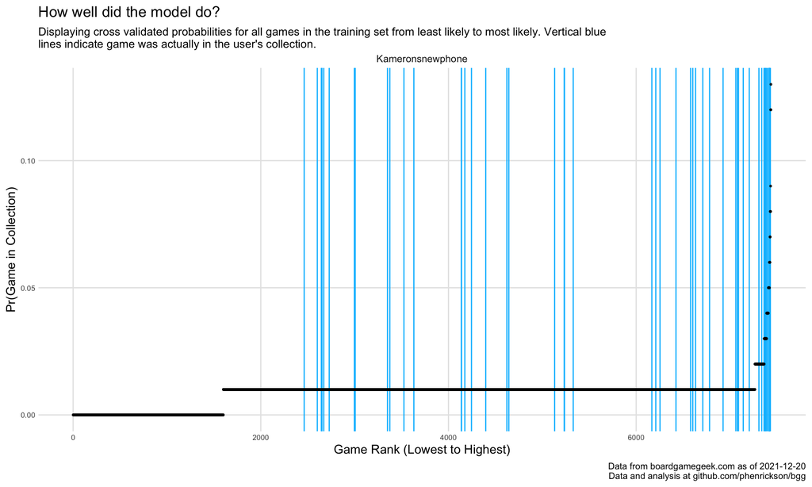

## 3.2 Top Games for **Kameronsnewphone** from Training Set

We can display this information in table form, displaying the 100 games with the highest probability of ownership, adding a blue line when the user does own the game.

| username | yearpublished | game_id | name | pred_played | pred_own | actual_played | actual_own |
| --- | --- | --- | --- | --- | --- | --- | --- |
| Kameronsnewphone | 2019 | 286096 | Tapestry | 0.13 | 0.13 | 0 | 0 |
| Kameronsnewphone | 2019 | 270971 | Era: Medieval Age | 0.12 | 0.12 | 0 | 0 |
| Kameronsnewphone | 2005 | 17133 | Railways of the World | 0.12 | 0.12 | 0 | 0 |
| Kameronsnewphone | 2012 | 120677 | Terra Mystica | 0.09 | 0.09 | 0 | 0 |
| Kameronsnewphone | 1995 | 13 | Catan | 0.08 | 0.08 | 0 | 0 |
| Kameronsnewphone | 2016 | 177736 | A Feast for Odin | 0.08 | 0.08 | 1 | 1 |
| Kameronsnewphone | 2019 | 276025 | Maracaibo | 0.08 | 0.08 | 0 | 0 |
| Kameronsnewphone | 2012 | 128780 | Pax Porfiriana | 0.08 | 0.08 | 0 | 0 |
| Kameronsnewphone | 1933 | 1406 | Monopoly | 0.07 | 0.07 | 0 | 0 |
| Kameronsnewphone | 1995 | 46 | Medici | 0.07 | 0.07 | 0 | 0 |
| Kameronsnewphone | 2014 | 161882 | Irish Gauge | 0.07 | 0.07 | 0 | 0 |
| Kameronsnewphone | 2018 | 244711 | Newton | 0.06 | 0.06 | 0 | 0 |
| Kameronsnewphone | 2017 | 218603 | Photosynthesis | 0.06 | 0.06 | 0 | 0 |
| Kameronsnewphone | 2018 | 247763 | Underwater Cities | 0.06 | 0.06 | 0 | 0 |
| Kameronsnewphone | 2017 | 174430 | Gloomhaven | 0.06 | 0.06 | 1 | 1 |
| Kameronsnewphone | 2019 | 251247 | Barrage | 0.06 | 0.06 | 1 | 1 |
| Kameronsnewphone | 2016 | 205398 | Citadels | 0.06 | 0.06 | 0 | 0 |
| Kameronsnewphone | 2014 | 163412 | Patchwork | 0.05 | 0.05 | 0 | 0 |
| Kameronsnewphone | 2019 | 281259 | The Isle of Cats | 0.05 | 0.05 | 0 | 0 |
| Kameronsnewphone | 2015 | 204184 | Risk: Europe | 0.05 | 0.05 | 0 | 0 |
| Kameronsnewphone | 2017 | 193728 | Pendragon: The Fall of Roman Britain | 0.05 | 0.05 | 0 | 0 |
| Kameronsnewphone | 2018 | 199792 | Everdell | 0.05 | 0.05 | 0 | 0 |
| Kameronsnewphone | 2017 | 220308 | Gaia Project | 0.05 | 0.05 | 1 | 1 |
| Kameronsnewphone | 2014 | 146886 | La Granja | 0.05 | 0.05 | 0 | 0 |
| Kameronsnewphone | 2015 | 182028 | Through the Ages: A New Story of Civilization | 0.05 | 0.05 | 1 | 1 |
| Kameronsnewphone | 2019 | 266507 | Clank!: Legacy – Acquisitions Incorporated | 0.05 | 0.05 | 0 | 0 |
| Kameronsnewphone | 2016 | 167791 | Terraforming Mars | 0.05 | 0.05 | 1 | 1 |
| Kameronsnewphone | 2018 | 205896 | Rising Sun | 0.05 | 0.05 | 0 | 0 |
| Kameronsnewphone | 1973 | 2995 | Sniper! | 0.04 | 0.04 | 0 | 0 |
| Kameronsnewphone | 2010 | 62227 | Labyrinth: The War on Terror, 2001 – ? | 0.04 | 0.04 | 0 | 0 |

[output cut: 70 more lines]

We can also more formally assess how well the model did in resampling by looking at the area under the receiver operating characteristic. A perfect model would receive a score of 1, while a model that cannot predict the outcome will default to a score of 0.5. The extent to which something is a *good* score depends on the setting, but generally anything in the .8 to .9 range is very good while the .7 to .8 range is perfectly acceptable.

| username | outcome_type | .metric | .estimator | .estimate |
| --- | --- | --- | --- | --- |
| Kameronsnewphone | own | roc_auc | binary | 0.874 |
| Kameronsnewphone | played | roc_auc | binary | 0.874 |

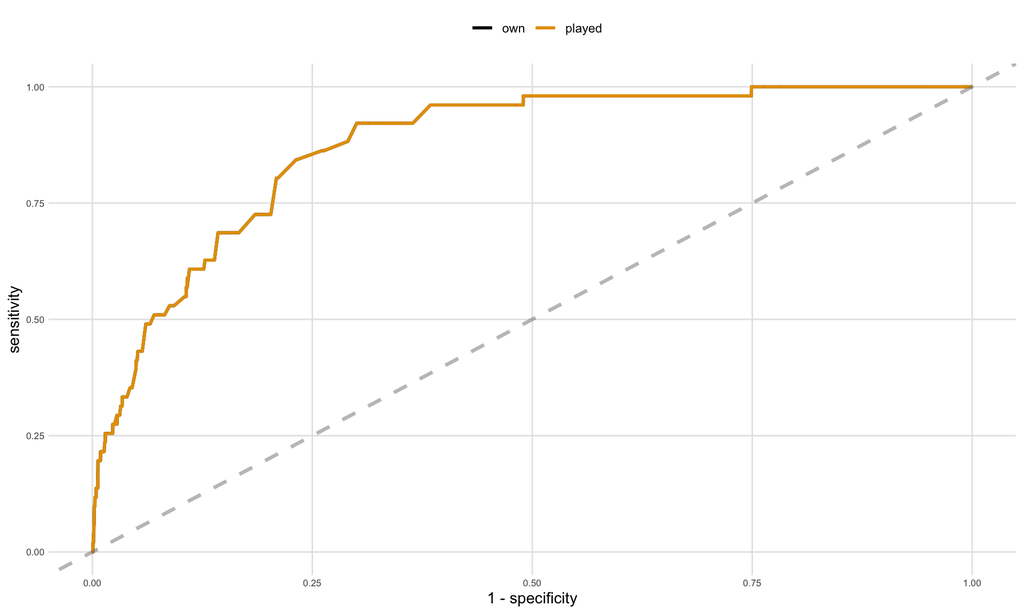

Another way to think about the model performance is to view its lift, or its ability to detect the positive outcomes over that of a null model. High lift indicates the model can much more quickly find all of the positive outcomes (in this case, games owned or played by the user), while a model with no lift is no better than random guessing.

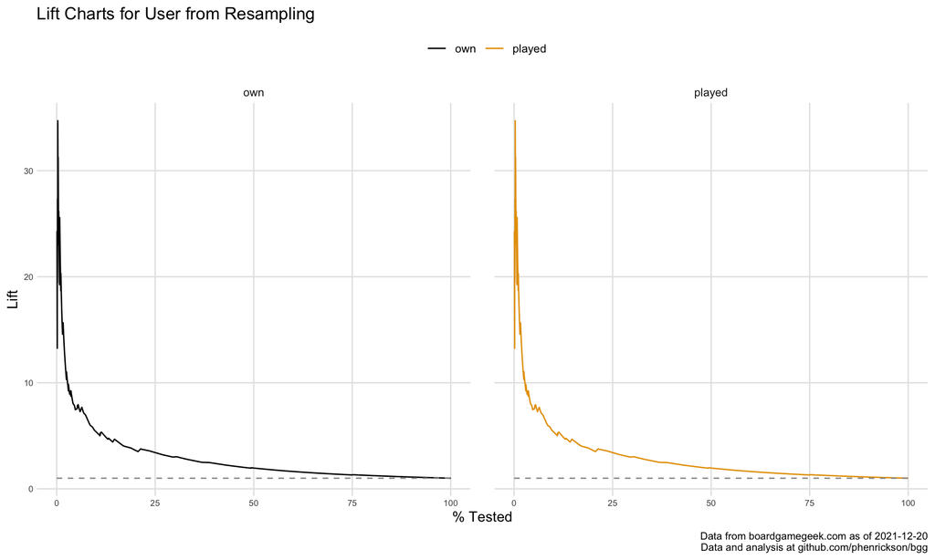

## 3.3 Most and Least Likely Games

What games does the model think Kameronsnewphone is **most likely to own** that are **not** in their collection?

| username | yearpublished | game_id | name | pred_own | actual_own |
| --- | --- | --- | --- | --- | --- |
| Kameronsnewphone | 2019 | 286096 | Tapestry | 0.13 | 0 |
| Kameronsnewphone | 2019 | 270971 | Era: Medieval Age | 0.12 | 0 |
| Kameronsnewphone | 2005 | 17133 | Railways of the World | 0.12 | 0 |
| Kameronsnewphone | 2012 | 120677 | Terra Mystica | 0.09 | 0 |
| Kameronsnewphone | 1995 | 13 | Catan | 0.08 | 0 |

What games does the model think Kameronsnewphone is **least likely to own** that **are** in their collection?

| username | yearpublished | game_id | name | pred_own | actual_own |
| --- | --- | --- | --- | --- | --- |
| Kameronsnewphone | 2011 | 43570 | Friday | 0.01 | 1 |
| Kameronsnewphone | 2011 | 84876 | The Castles of Burgundy | 0.01 | 1 |
| Kameronsnewphone | 2015 | 146508 | T.I.M.E Stories | 0.01 | 1 |
| Kameronsnewphone | 2014 | 155426 | Castles of Mad King Ludwig | 0.01 | 1 |
| Kameronsnewphone | 2015 | 172818 | Above and Below | 0.01 | 1 |

## 3.4 Top Games by Year

Top 25 games most likely to be owned by the user in each year, highlighting in blue the games that the user has owned/played.

| rank | 2011 | 2012 | 2013 | 2014 | 2015 | 2016 | 2017 | 2018 | 2019 |
| --- | --- | --- | --- | --- | --- | --- | --- | --- | --- |
| 1 | Space Empires: 4X | Terra Mystica | Prosperity | Irish Gauge | Risk: Europe | A Feast for Odin | Photosynthesis | Newton | Tapestry |
| 2 | Octopus's Garden | Pax Porfiriana | Impulse | Patchwork | Through the Ages: A New Story of Civilization | Citadels | Gloomhaven | Underwater Cities | Era: Medieval Age |
| 3 | Eclipse | Robinson Crusoe: Adventures on the Cursed Island | Friese's Landlord | La Granja | The Bloody Inn | Terraforming Mars | Pendragon: The Fall of Roman Britain | Everdell | Maracaibo |
| 4 | A Game of Thrones: The Board Game (Second Edition) | Kill the Overlord | Spyrium | Fields of Arle | The Voyages of Marco Polo | The Networks | Gaia Project | Rising Sun | Barrage |
| 5 | Band of Brothers: Screaming Eagles | Keyflower | LEADERS: The Combined Strategy Game | Sons of Anarchy: Men of Mayhem | The Pursuit of Happiness | Bohemian Villages | Dinosaur Island | Brass: Birmingham | The Isle of Cats |
| 6 | A Few Acres of Snow | Descent: Journeys in the Dark (Second Edition) | Room 25 | Five Tribes | Food Chain Magnate | Exceed Fighting System | Breaking Bad: The Board Game | Duelosaur Island | Clank!: Legacy – Acquisitions Incorporated |
| 7 | Sekigahara: The Unification of Japan | War of the Ring: Second Edition | Dungeon Command: Blood of Gruumsh | Power Grid Deluxe: Europe/North America | Burgle Bros. | Inis | Unfair | Renegade | Crystal Palace |
| 8 | Fighting Formations: Grossdeutschland Motorized Infantry Division | Spartacus: A Game of Blood and Treachery | Band of Brothers: Ghost Panzer | Spurs: A Tale in the Old West | Mombasa | Yokohama | This War of Mine: The Board Game | Franchise | Florenza Dice Game |
| 9 | No Retreat! The Russian Front | Wiz-War (Eighth Edition) | BattleLore: Second Edition | Saint Petersburg (Second Edition) | 504 | Aventuria: Adventure Card Game | Twilight Imperium: Fourth Edition | Kero | Sierra West |
| 10 | Nightfighter | Exodus: Proxima Centauri | No Retreat!: The North African Front | Dead of Winter: A Crossroads Game | Tiny Epic Galaxies | Falling Sky: The Gallic Revolt Against Caesar | Aristeia! | The Order of Vampire Hunters | Tainted Grail: The Fall of Avalon |
| 11 | Space Infantry | Bolt Action | Crusade and Revolution: The Spanish Civil War, 1936-1939 | Star Wars: Imperial Assault | Stronghold: 2nd edition | Clank!: A Deck-Building Adventure | Mythic Battles: Pantheon | Founders of Gloomhaven | Hellenica: Story of Greece |
| 12 | No Peace Without Spain!: The War of the Spanish Succession 1702-1713 | Archipelago | Sedition Wars: Battle for Alabaster | Fallen | Wing Leader: Victories 1940-1942 | Islebound | Spirit Island | Pax Emancipation | Hearts and Minds: Vietnam 1965-1975 (Third Edition) |
| 13 | FAB: Sicily | Kings of War | Dungeon Twister: The Card Game | Holdfast: Russia 1941-42 | Warhammer Age of Sigmar | Mechs vs. Minions | Too Many Bones | Dead Man's Doubloons | The Magnificent |
| 14 | Test of Fire: Bull Run 1861 | Mage Wars Arena | Risk: Plants vs. Zombies | Heroes of Normandie | The U.S. Civil War | Crazy Karts | 878 Vikings: Invasions of England | Betrayal Legacy | Cloudspire |
| 15 | Steam Torpedo: First Contact | Dungeon Command: Sting of Lolth | Metallum | Strife: Legacy of the Eternals | Guild Ball | The Oregon Trail Card Game | Clans of Caledonia | Nemesis | Middara: Unintentional Malum – Act 1 |
| 16 | Yomi | Dungeon Command: Heart of Cormyr | Castellan | Star Wars: Empire vs. Rebellion | BattleCON: Fate of Indines | Old School Tactical: Volume 1 – Fighting on the Eastern Front 1941/42 | Summit: The Board Game | Gettysburg | Last Bastion |
| 17 | Laser Chess | Dungeon Command: Curse of Undeath | Smash Up: Awesome Level 9000 | Fleet Commander: 1 – Ignition | The Great War | Silent Victory: U.S. Submarines in the Pacific, 1941-45 | Techno Bowl: Arcade Football Unplugged | Star Wars: Legion | Posthuman Saga |
| 18 | Omen: A Reign of War | DreadBall: The Futuristic Sports Game | Pixel Tactics 2 | Jäger und Späher | The Horus Heresy: Betrayal at Calth | Wing Leader: Supremacy 1943-1945 | Commands & Colors Tricorne: The American Revolution | Too Many Bones: Undertow | Arena: The Contest |
| 19 | Ascension: Return of the Fallen | Kingdom of Heaven: The Crusader States 1097-1291 | Smash Up: The Obligatory Cthulhu Set | Space Hulk (Fourth Edition) | ...and then, we held hands. | MBT (Second Edition) | Runewars Miniatures Game | Nightfighter Ace: Air Defense Over Germany, 1943-44 | Amul |
| 20 | Drako: Dragon & Dwarves | Celles: The Ardennes, December 23-27, 1944 | The Ravens of Thri Sahashri | Wir sind das Volk! | Smash Up: Pretty Pretty Smash Up | Smash Up: It's Your Fault! | Fields of Despair: France 1914-1918 | 1066, Tears to Many Mothers | Coloma |
| 21 | Hemloch | Antike Duellum | The Dark Valley | The Battle of Five Armies | Pixel Tactics 4 | Heir to the Pharaoh | Enemy Coast Ahead: The Doolittle Raid | Skies Above the Reich | Tiny Towns |
| 22 | Infidel | Targi | Batman: Arkham City Escape | Ortus Regni | Trambahn | Deathwatch: Overkill | 13 Minutes: The Cuban Missile Crisis, 1962 | A Song of Ice & Fire: Tabletop Miniatures Game – Stark vs Lannister Starter Set | Dune |
| 23 | Advanced Squad Leader: Starter Kit Expansion Pack #1 | Game of Thrones: The Card Game | Asante | Smash Up: Science Fiction Double Feature | Die Legenden von Andor: Chada & Thorn | Mini Rogue: A 9-Card Print-and-Play Game | Tak | Crystal Clans | Ragusa |
| 24 | Carnac | For the Crown (Second Edition) | The Duke | Akrotiri | Haleakala | Guild Ball: Kick Off! | LYNGK | Dual Powers: Revolution 1917 | Claustrophobia 1643 |
| 25 | 1911 Amundsen vs Scott | 1989: Dawn of Freedom | Dungeon Heroes | Smash Up: Monster Smash | Castellion | Tokyo Highway | Konja | Blitz Bowl | The Last Hundred Yards |

## 3.5 Interactive Predictions from Resampling

Interactive table for predictions from resampling.

|  | username | yearpublished | rank | game_id | name | pred_played | pred_own | actual_played | actual_own |
| --- | --- | --- | --- | --- | --- | --- | --- | --- | --- |
| 1 | Kameronsnewphone | 1900 | 221 | 188 | Go | 0.01 | 0.01 | 0 | 0 |
| 2 | Kameronsnewphone | 1900 | 322 | 171 | Chess | 0.01 | 0.01 | 0 | 0 |
| 3 | Kameronsnewphone | 1900 | 331 | 2065 | Shogi | 0.01 | 0.01 | 0 | 0 |
| 4 | Kameronsnewphone | 1900 | 537 | 26952 | International Checkers | 0.01 | 0.01 | 0 | 0 |
| 5 | Kameronsnewphone | 1900 | 564 | 1602 | The Royal Game of Ur | 0.01 | 0.01 | 0 | 0 |
| 6 | Kameronsnewphone | 1900 | 565 | 2083 | Checkers | 0.01 | 0.01 | 0 | 0 |
| 7 | Kameronsnewphone | 1900 | 571 | 2389 | Othello | 0.01 | 0.01 | 0 | 0 |
| 8 | Kameronsnewphone | 1900 | 572 | 2397 | Backgammon | 0.01 | 0.01 | 0 | 0 |
| 9 | Kameronsnewphone | 1900 | 573 | 2399 | Senet | 0.01 | 0.01 | 0 | 0 |
| 10 | Kameronsnewphone | 1900 | 811 | 315 | Bagh Chal | 0.01 | 0.01 | 0 | 0 |

[output cut: 7426 more lines]

# 4 Validating the Model on 2020

How well did a model trained on a user’s collection through 2019 perform in predicting games for the user from 2020?

| username | outcome_type | yearpublished | .metric | .estimator | .estimate |
| --- | --- | --- | --- | --- | --- |
| Kameronsnewphone | own | 2020 | roc_auc | binary | 0.875 |
| Kameronsnewphone | played | 2020 | roc_auc | binary | 0.875 |

Table of top 25 games from 2020, highlighting games that the user owns.

| username | yearpublished | game_id | name | pred_own | pred_played | actual_own | actual_played |
| --- | --- | --- | --- | --- | --- | --- | --- |
| Kameronsnewphone | 2020 | 256317 | Guild Master | 0.14 | 0.14 | 0 | 0 |
| Kameronsnewphone | 2020 | 184267 | On Mars | 0.12 | 0.12 | 0 | 0 |
| Kameronsnewphone | 2020 | 246900 | Eclipse: Second Dawn for the Galaxy | 0.10 | 0.10 | 0 | 0 |
| Kameronsnewphone | 2020 | 294788 | Conqueror: Final Conquest | 0.07 | 0.07 | 0 | 0 |
| Kameronsnewphone | 2020 | 300322 | Hallertau | 0.07 | 0.07 | 0 | 0 |
| Kameronsnewphone | 2020 | 294047 | Superclub | 0.05 | 0.05 | 0 | 0 |
| Kameronsnewphone | 2020 | 303057 | Pan Am | 0.05 | 0.05 | 0 | 0 |
| Kameronsnewphone | 2020 | 308765 | Praga Caput Regni | 0.05 | 0.05 | 0 | 0 |
| Kameronsnewphone | 2020 | 310442 | Feierabend | 0.05 | 0.05 | 0 | 0 |
| Kameronsnewphone | 2020 | 320819 | Dinner in Paris | 0.05 | 0.05 | 0 | 0 |
| Kameronsnewphone | 2020 | 291457 | Gloomhaven: Jaws of the Lion | 0.04 | 0.04 | 1 | 1 |
| Kameronsnewphone | 2020 | 292333 | Cowboys II: Cowboys & Indians Edition | 0.04 | 0.04 | 0 | 0 |
| Kameronsnewphone | 2020 | 297030 | Tekhenu: Obelisk of the Sun | 0.04 | 0.04 | 0 | 0 |
| Kameronsnewphone | 2020 | 217990 | Stellar Horizons | 0.03 | 0.03 | 0 | 0 |
| Kameronsnewphone | 2020 | 295577 | Dungeon Mayhem: Monster Madness | 0.03 | 0.03 | 0 | 0 |
| Kameronsnewphone | 2020 | 305270 | Chronicles of Waral | 0.03 | 0.03 | 0 | 0 |
| Kameronsnewphone | 2020 | 256940 | Krosmaster: Blast | 0.02 | 0.02 | 0 | 0 |
| Kameronsnewphone | 2020 | 262274 | D6: Dungeons, Dudes, Dames, Danger, Dice and Dragons! | 0.02 | 0.02 | 0 | 0 |
| Kameronsnewphone | 2020 | 282922 | Windward | 0.02 | 0.02 | 0 | 0 |
| Kameronsnewphone | 2020 | 295905 | Cosmic Frog | 0.02 | 0.02 | 0 | 0 |
| Kameronsnewphone | 2020 | 299179 | Chancellorsville 1863 | 0.02 | 0.02 | 0 | 0 |
| Kameronsnewphone | 2020 | 302465 | Obsidia | 0.02 | 0.02 | 0 | 0 |
| Kameronsnewphone | 2020 | 306735 | Under Falling Skies | 0.02 | 0.02 | 0 | 0 |
| Kameronsnewphone | 2020 | 308652 | Age of Dogfights: WW1 | 0.02 | 0.02 | 0 | 0 |
| Kameronsnewphone | 2020 | 316750 | The Princess Bride Adventure Book Game | 0.02 | 0.02 | 0 | 0 |

# 5 Predicting Upcoming Games (2020 and On) for **Kameronsnewphone**

Examine the top games for the test set.

Top Predicted Games for User, 2019 and On

| username | yearpublished | game_id | name | rank | own | played |
| --- | --- | --- | --- | --- | --- | --- |
| Kameronsnewphone | 2020 | 256317 | Guild Master | 1 | 0.14 | 0.14 |
| Kameronsnewphone | 2020 | 184267 | On Mars | 2 | 0.12 | 0.12 |
| Kameronsnewphone | 2020 | 246900 | Eclipse: Second Dawn for the Galaxy | 3 | 0.10 | 0.10 |
| Kameronsnewphone | 2020 | 294788 | Conqueror: Final Conquest | 4 | 0.07 | 0.07 |
| Kameronsnewphone | 2020 | 300322 | Hallertau | 5 | 0.07 | 0.07 |
| Kameronsnewphone | 2020 | 294047 | Superclub | 6 | 0.05 | 0.05 |
| Kameronsnewphone | 2020 | 310442 | Feierabend | 7 | 0.05 | 0.05 |
| Kameronsnewphone | 2020 | 320819 | Dinner in Paris | 8 | 0.05 | 0.05 |
| Kameronsnewphone | 2020 | 303057 | Pan Am | 9 | 0.05 | 0.05 |
| Kameronsnewphone | 2020 | 308765 | Praga Caput Regni | 10 | 0.05 | 0.05 |
| Kameronsnewphone | 2020 | 291457 | Gloomhaven: Jaws of the Lion | 11 | 0.04 | 0.04 |
| Kameronsnewphone | 2020 | 297030 | Tekhenu: Obelisk of the Sun | 12 | 0.04 | 0.04 |
| Kameronsnewphone | 2020 | 292333 | Cowboys II: Cowboys & Indians Edition | 13 | 0.04 | 0.04 |
| Kameronsnewphone | 2020 | 305270 | Chronicles of Waral | 14 | 0.03 | 0.03 |
| Kameronsnewphone | 2020 | 217990 | Stellar Horizons | 15 | 0.03 | 0.03 |
| Kameronsnewphone | 2020 | 295577 | Dungeon Mayhem: Monster Madness | 16 | 0.03 | 0.03 |
| Kameronsnewphone | 2020 | 306735 | Under Falling Skies | 17 | 0.02 | 0.02 |
| Kameronsnewphone | 2020 | 316750 | The Princess Bride Adventure Book Game | 18 | 0.02 | 0.02 |
| Kameronsnewphone | 2020 | 326767 | Infinity N4: Core Rules | 19 | 0.02 | 0.02 |
| Kameronsnewphone | 2020 | 256940 | Krosmaster: Blast | 20 | 0.02 | 0.02 |
| Kameronsnewphone | 2020 | 262274 | D6: Dungeons, Dudes, Dames, Danger, Dice and Dragons! | 21 | 0.02 | 0.02 |
| Kameronsnewphone | 2020 | 282922 | Windward | 22 | 0.02 | 0.02 |
| Kameronsnewphone | 2020 | 295905 | Cosmic Frog | 23 | 0.02 | 0.02 |
| Kameronsnewphone | 2020 | 299179 | Chancellorsville 1863 | 24 | 0.02 | 0.02 |
| Kameronsnewphone | 2020 | 302465 | Obsidia | 25 | 0.02 | 0.02 |
| Kameronsnewphone | 2021 | 310873 | Carnegie | 1 | 0.12 | 0.12 |
| Kameronsnewphone | 2021 | 343905 | Boonlake | 2 | 0.09 | 0.09 |
| Kameronsnewphone | 2021 | 295535 | Dark Ages: Heritage of Charlemagne | 3 | 0.06 | 0.06 |
| Kameronsnewphone | 2021 | 304985 | Dark Ages: Holy Roman Empire | 4 | 0.06 | 0.06 |
| Kameronsnewphone | 2021 | 342942 | Ark Nova | 5 | 0.06 | 0.06 |
| Kameronsnewphone | 2021 | 320446 | Corduba 27 a.C. | 6 | 0.05 | 0.05 |
| Kameronsnewphone | 2021 | 309319 | Apogee | 7 | 0.05 | 0.05 |
| Kameronsnewphone | 2021 | 328569 | Mint Bid | 8 | 0.05 | 0.05 |
| Kameronsnewphone | 2021 | 298383 | Golem | 9 | 0.04 | 0.04 |
| Kameronsnewphone | 2021 | 299684 | Khôra: Rise of an Empire | 10 | 0.04 | 0.04 |
| Kameronsnewphone | 2021 | 328871 | Terraforming Mars: Ares Expedition | 11 | 0.04 | 0.04 |
| Kameronsnewphone | 2021 | 238799 | Messina 1347 | 12 | 0.04 | 0.04 |
| Kameronsnewphone | 2021 | 292375 | The Great Wall | 13 | 0.04 | 0.04 |
| Kameronsnewphone | 2021 | 319793 | Happy City | 14 | 0.03 | 0.03 |
| Kameronsnewphone | 2021 | 327971 | Hippocrates | 15 | 0.03 | 0.03 |
| Kameronsnewphone | 2021 | 330665 | Bellum Magica | 16 | 0.03 | 0.03 |
| Kameronsnewphone | 2021 | 290618 | Wishland | 17 | 0.03 | 0.03 |
| Kameronsnewphone | 2021 | 317457 | Dinosaur World | 18 | 0.03 | 0.03 |
| Kameronsnewphone | 2021 | 341256 | Murano: Light Masters | 19 | 0.03 | 0.03 |
| Kameronsnewphone | 2021 | 259962 | Stress Botics | 20 | 0.02 | 0.02 |
| Kameronsnewphone | 2021 | 300217 | Merchants of the Dark Road | 21 | 0.02 | 0.02 |
| Kameronsnewphone | 2021 | 301366 | Caves of Rwenzori | 22 | 0.02 | 0.02 |
| Kameronsnewphone | 2021 | 340909 | Gloomholdin' | 23 | 0.02 | 0.02 |
| Kameronsnewphone | 2021 | 285967 | Ankh: Gods of Egypt | 24 | 0.02 | 0.02 |
| Kameronsnewphone | 2021 | 295785 | Euthia: Torment of Resurrection | 25 | 0.02 | 0.02 |
| Kameronsnewphone | 2022 | 330950 | Age of Galaxy | 1 | 0.05 | 0.05 |
| Kameronsnewphone | 2022 | 331106 | The Witcher: Old World | 2 | 0.03 | 0.03 |
| Kameronsnewphone | 2022 | 295770 | Frosthaven | 3 | 0.03 | 0.03 |
| Kameronsnewphone | 2022 | 317511 | Tindaya | 4 | 0.03 | 0.03 |
| Kameronsnewphone | 2022 | 322524 | Bardsung | 5 | 0.03 | 0.03 |
| Kameronsnewphone | 2022 | 284189 | Foundations of Rome | 6 | 0.03 | 0.03 |
| Kameronsnewphone | 2022 | 295895 | Distilled | 7 | 0.03 | 0.03 |
| Kameronsnewphone | 2022 | 256680 | Return to Dark Tower | 8 | 0.02 | 0.02 |
| Kameronsnewphone | 2022 | 338067 | 6: Siege – The Board Game | 9 | 0.02 | 0.02 |
| Kameronsnewphone | 2022 | 283137 | Human Punishment: The Beginning | 10 | 0.02 | 0.02 |
| Kameronsnewphone | 2022 | 273814 | Deliverance | 11 | 0.02 | 0.02 |
| Kameronsnewphone | 2022 | 317321 | Darkest Dungeon: The Board Game | 12 | 0.02 | 0.02 |
| Kameronsnewphone | 2022 | 253759 | Paint the Roses | 13 | 0.01 | 0.01 |
| Kameronsnewphone | 2022 | 266592 | TacTiki | 14 | 0.01 | 0.01 |
| Kameronsnewphone | 2022 | 288080 | Dice Realms | 15 | 0.01 | 0.01 |
| Kameronsnewphone | 2022 | 328866 | My Father's Work | 16 | 0.01 | 0.01 |
| Kameronsnewphone | 2022 | 330973 | Volfyirion Guilds | 17 | 0.01 | 0.01 |
| Kameronsnewphone | 2022 | 260923 | Titan | 18 | 0.01 | 0.01 |
| Kameronsnewphone | 2022 | 274277 | Jurassic World Miniature Game | 19 | 0.01 | 0.01 |
| Kameronsnewphone | 2022 | 293941 | Mage Noir | 20 | 0.01 | 0.01 |
| Kameronsnewphone | 2022 | 312512 | The Transcontinental | 21 | 0.01 | 0.01 |
| Kameronsnewphone | 2022 | 313807 | Oros | 22 | 0.01 | 0.01 |
| Kameronsnewphone | 2022 | 315695 | Veiled Fate | 23 | 0.01 | 0.01 |
| Kameronsnewphone | 2022 | 318450 | Bios: Mesofauna | 24 | 0.01 | 0.01 |
| Kameronsnewphone | 2022 | 327711 | It's a Wonderful Kingdom | 25 | 0.01 | 0.01 |

## 5.1 Interactive Table for Upcoming Games 2020 and On

|  | username | yearpublished | game_id | name | rank | own | played |
| --- | --- | --- | --- | --- | --- | --- | --- |
| 1 | Kameronsnewphone | 2020 | 256317 | Guild Master | 1 | 0.14 | 0.14 |
| 2 | Kameronsnewphone | 2020 | 184267 | On Mars | 2 | 0.12 | 0.12 |
| 3 | Kameronsnewphone | 2021 | 310873 | Carnegie | 3 | 0.12 | 0.12 |
| 4 | Kameronsnewphone | 2020 | 246900 | Eclipse: Second Dawn for the Galaxy | 4 | 0.1 | 0.1 |
| 5 | Kameronsnewphone | 2021 | 343905 | Boonlake | 5 | 0.09 | 0.09 |
| 6 | Kameronsnewphone | 2020 | 294788 | Conqueror: Final Conquest | 6 | 0.07 | 0.07 |
| 7 | Kameronsnewphone | 2020 | 300322 | Hallertau | 7 | 0.07 | 0.07 |
| 8 | Kameronsnewphone | 2021 | 295535 | Dark Ages: Heritage of Charlemagne | 8 | 0.06 | 0.06 |
| 9 | Kameronsnewphone | 2021 | 304985 | Dark Ages: Holy Roman Empire | 9 | 0.06 | 0.06 |
| 10 | Kameronsnewphone | 2021 | 342942 | Ark Nova | 10 | 0.06 | 0.06 |

[output cut: 1627 more lines]